# Lab 4, Zad 1

## Problem komiwojażera

### Import bibliotek

```python
import numpy as np
import matplotlib.pyplot as plt
import math
from PIL import Image
import io
```

# Definicja

Symulowane wyżarzanie (Simulated Annealing, SA) to probabilistyczna metoda optymalizacji, inspirowana procesem fizycznym wyżarzania metali. Celem algorytmu jest znalezienie minimum (lub maksimum) funkcji celu poprzez stopniowe "schładzanie" systemu. Proces zaczyna się od wysokiej temperatury, która pozwala na przyjęcie zarówno gorszych, jak i lepszych rozwiązań, a następnie temperatura stopniowo maleje. Z czasem algorytm staje się bardziej ukierunkowany na poszukiwanie lokalnych minimów, co prowadzi do osiągnięcia optymalnego lub zbliżonego rozwiązania.

### Funkcje generujące punkty

Funkcja `gen_random_points(n,min_val, max_val)` zwraca punkty z rozkładu jednostajnego w na kwadracie o punktach skrajnych w (min_val, min_val) i (max_val, max_val)

```python
def gen_random_points(n,min_val = -10,max_val = 10):
    return np.random.uniform(min_val,max_val,size = (n,2))
```

Funkcja `gen_four_spots(n,min_val, max_val)` zwraca punkty, które są rozsiane w czterech skupiskach na rogach kwadratu o punktach skrajnych w (min_val, min_val) i (max_val, max_val)

```python
def gen_four_spots(n,min_val,max_val):
    n1 = n2 = n3 = n//4
    n4 = n - n1 - n2 - n3
    scale = (max_val - min_val) / 30
    points = []
    cov = [[scale, 0], [0, scale]]
    points.extend(np.random.multivariate_normal([min_val,min_val], cov, n1))
    points.extend(np.random.multivariate_normal([min_val,max_val], cov, n2))
    points.extend(np.random.multivariate_normal([max_val,min_val], cov, n3))
    points.extend(np.random.multivariate_normal([max_val,max_val], cov, n4))
    # przetasowanie
    np.random.shuffle(points)
    return points
```

Funkcja `gen_nine_spots(n, min_val, max_val)` generuje punkty rozmieszczone w dziewięciu skupiskach, zlokalizowanych w rogach, na środku boków oraz w centrum kwadratu o przeciwległych wierzchołkach w punktach (min_val, min_val), (min_val, min_val) oraz (max_val, max_val), (max_val, max_val).

```python
def gen_nine_spots(n, min_val, max_val):
    num_clusters = 9
    n_per_cluster = n // num_clusters
    leftover = n - n_per_cluster * num_clusters

    scale = (max_val - min_val) / 70
    cov = [[scale, 0], [0, scale]]

    cluster_centers = []
    steps = np.linspace(min_val, max_val, 3)
    for x in steps:
        for y in steps:
            cluster_centers.append([x, y])

    points = []
    for i, center in enumerate(cluster_centers):
        count = n_per_cluster + (1 if i < leftover else 0)  # rozdziel resztę
        cluster = np.random.multivariate_normal(center, cov, count)
        points.extend(cluster)
    np.random.shuffle(points)
    return np.array(points)
```

### Funkcje odpowiedzialne za wizualizacje

Funkcja `plot_points(points)` rysuje za pomocą matplotlib punkty na płaszczyźnie

```python
def plot_points(points):
    """
    Rysuje punkty dwuwymiarowe podane w formie listy krotek (x, y).

    :param points: Lista krotek [(x1, y1), (x2, y2), ...]
    """
    x_values, y_values = zip(*points)  # Rozpakowanie współrzędnych

    plt.figure(figsize=(6, 4))
    plt.scatter(x_values, y_values, c='blue', marker='o')

    plt.xlabel("X")
    plt.ylabel("Y")
    plt.title("Wykres punktów 2D")
    plt.grid(True, linestyle='--', alpha=0.6)

    plt.show()
```

Funkcje `draw_segments(points)` rysuje wizualizacje znalezionej cyklu na podstawie tablicy points.

Funkcja `draw_linear_plot(distance_tab)` tworzy wykres liniowy na podstawie tablicy przyjętej jako argument

```python
def draw_segments(points, val = None, path = None):
    points = np.array(points)


    # Rysowanie krawędzi z lepszą kolorystyką
    for i in range(0, len(points)):
        x_values = [points[i-1][0], points[i][0]]
        y_values = [points[i-1][1], points[i][1]]
        plt.plot(x_values, y_values, color='#3498db', linewidth=2, alpha=0.8)  # Niebieski, grubsza linia


    # Rysowanie wszystkich punktów na czerwono
    plt.scatter(points[:, 0], points[:, 1], color='#e74c3c', s=50, zorder=5, edgecolors='white', linewidth=1.5)


    # Ulepszony styl dla tytułu i podpisu
    if val and path:
        plt.title(f"Znaleziono cykl dla {path} \no wadze {val:.2f}")
    elif val:
        plt.title(f"Znaleziono cykl o wadze {val:.2f}")
    elif path:
        plt.title(f"Znajdowanie cykl dla {path}")

def draw_linear_plot(distance_tab, path = None):
    plt.figure()
    plt.title(f"Wykres funkcji długości cyklu dla {path}")
    plt.xlabel('Liczba iterazcji')
    plt.ylabel('Wyliczony dystans')
    plt.plot(distance_tab)
    plt.show()
```

Funkcja `extend_gif(points, images, new_val, i)` dodaje do struktury images klatke obrazu jako wizualizacja aktualnie najlepszego znalezionego rozwiązania

```python
def extend_gif(points, images, new_val, i, gif_name):
    fig, ax = plt.subplots(figsize=(6, 6))
    draw_segments(points)  # Rysowanie segmentów
    ax.scatter(points[:, 0], points[:, 1], s=10)
    ax.set_title(f"Znajdowanie cyklu dla {gif_name}\nLiczba iteracji {i+1}, Dystans: {new_val:.2f}")
    ax.axis('equal')

    # Zapisz wykres do pamięci (do obiektu BytesIO)
    buf = io.BytesIO()  # Pamięć wirtualna
    plt.savefig(buf, format='png')
    buf.seek(0)  # Przesuń wskaźnik na początek
    img = Image.open(buf)
    images.append(img)  # Dodaj obraz do listy obrazków

    # Zresetuj wykres
    plt.close(fig)
    return images
```

## Główna część rozwiązania

### Funkcja licząca prawdopodobieństwo

Do rozwiązania zadania użyłem funkcji prawdopodobieństwa zgodnej z rozkładem Boltzmana. Ma ona wzór:

$$ P(\text{zmiany}) = e^{-\frac{\text{RóżnicaEnergiiStanów}}{\text{Temperatura}}} $$

poniżej przedstawiam implementacje tej funkji

```python
def propability(diffrance, Temp):
    if diffrance < 0:
        return 1
    return np.exp(-diffrance/ Temp)
```

*dla różnicy, która polepsza wynik, funkcja od razu zwraca 1 (zawsze opłaca się przejść do stanu lepszego)

## Określenie funkcji do minimalizacji

W algorytmie optymalizowana jest długość trasy obliczana przy użyciu metryki euklidesowej. Choć możliwa jest implementacja innych metryk, w niniejszym sprawozdaniu ograniczam się wyłącznie do tej jednej.

**Uwaga:** Zakładam, że długość trasy obliczana jest na podstawie kolejności punktów w tablicy początkowej. Trasa tworzona jest przez łączenie kolejnych sąsiadujących ze sobą punktów w tablicy, zaczynając od pierwszego elementu.

Funkcja `get_path_total_distance(T)` jawnie liczy długość całej trasy na podstwie tablicy T

```python
def get_path_total_distance(T):
    T = np.array(T)
    diffs = T[1:] - T[:-1]
    distances = np.linalg.norm(diffs, axis=1)
    distances.append(math.sqrt((T[0][0] - T[-1][0])**2 +(T[0][1] - T[-1][1])**2 ))
    return np.sum(distances)
```

### Sposób liczenia funkcji minimalizującej

W celu zoptymalizowania działania algorytmu, nie przeliczam całkowitej długości trasy po każdej zmianie kolejności punktów w tablicy. Zamiast tego, aktualizuję wynik na podstawie wcześniejszego stanu, dokonując lokalnej korekty. Obliczam różnicę, odejmując długość zmodyfikowanych krawędzi po zmianie od ich długości przed zmianą — analizując jedynie otoczenie zmienianych punktów. Dzięki temu operacja ta ma stałą złożoność obliczeniową O(1), co znacząco przyspiesza działanie algorytmu.

Funkcja `get_distance_from_point(points, point, index)` liczy wartość cyklu między sąsiadami punktu point. sąsiedzi są określani na podstawie indeksu w tablicy points

```python
def get_distance_from_point(points, point, index):
    sum = 0
    if index > 0:
        sum += math.sqrt((point[0] - points[index-1][0])**2 +(point[1] - points[index-1][1])**2 )
    if index < len(points) - 1:
        sum += math.sqrt((point[0] - points[index+1][0])**2 +(point[1] - points[index+1][1])**2 )
    if index == 0:
        sum += math.sqrt((point[0] - points[-1][0])**2 +(point[1] - points[-1][1])**2 )
    if index == len(points) - 1:
        sum += math.sqrt((point[0] - points[0][0])**2 +(point[1] - points[0][1])**2 )
    return sum
```

Funkcja `get_diffrance_of_distance(points, index1, index2)` oblicza różnice między drogami po zmianie miejscami indeksów w tablicy points

```python
def get_diffrance_of_distance(points, index1, index2):
    # Obliczamy aktualne odległości przed zamianą
    n = len(points)
    current_distance = 0
    # Łączenie index1 z sąsiadami
    current_distance += get_distance_from_point(points, points[index1], index1)
    current_distance += get_distance_from_point(points, points[index2], index2)

    new_distance = 0

    new_distance += get_distance_from_point(points, points[index1], index2)
    new_distance += get_distance_from_point(points, points[index2], index1)
    # Podobnie unikamy podwójnego liczenia dla sąsiadów
    if abs(index1 - index2) == 1 or (index1==0 and index2 == n-1) or (index1==n-1 and index2 == 0):
        new_distance += 2* math.sqrt((points[index1][0] - points[index2][0])**2 + (points[index1][1] - points[index2][1])**2)
    # if (index1==0 and index2 == n-1) or (index1==n-1 and index2 == 0):
    #     new_distance += 2* math.sqrt((points[index1][0] - points[index2][0])**2 + (points[index1][1] - points[index2][1])**2)
    # Różnica to nowa odległość minus stara odległość
    return new_distance - current_distance
```

### Funkcje temperatury

Na potrzeby pogłębionej analizy problemu, zaimplementowałem 3 funkcje spadku temperatury:

- `update_temp_geo` - wykorzystuje wzór $ T_k = T_0 * a^k $
- `update_temp_linear` - wykorzystuje wzór $ T_k = T_0 - a * k $
- `update_temp_log` - wykorzystuje wzór $ T_k = T_0 / {log(1+k)} $

```python
def update_temp_geo(Temp, a, k ,temp_start):
    return a * Temp

def update_temp_linear(Temp, a, k ,temp_start):
    return max(Temp - a, 0.000001)
def update_temp_log(Temp, a, k ,temp_start):
    return temp_start / np.log(1 + k+1)
```

### Główna funkcja

`Funkcja tsp_with_gif` implementuje algorytm symulowanego wyżarzania (simulated annealing) w celu przybliżonego rozwiązania problemu komiwojażera (TSP – Travelling Salesman Problem). Dodatkowo, funkcja może generować animację GIF przedstawiającą proces optymalizacji trasy.

Parametry: `points` – lista współrzędnych punktów reprezentujących miasta (dowolna permutacja punktów w przestrzeni dwuwymiarowej).

`temp_start` – wartość początkowej temperatury, od której rozpoczyna się proces wyżarzania.

`loop_limit` – maksymalna liczba iteracji algorytmu.

`min_temp` – minimalna dopuszczalna temperatura, przy której algorytm może jeszcze działać (domyślnie 1e-2).

`fun_change_par` – parametr regulujący tempo obniżania temperatury (stosowany w funkcji aktualizującej temperaturę).

`fun_temp_change` – funkcja odpowiedzialna za aktualizację temperatury; domyślnie zastosowana jest metoda wyżarzania geometrycznego.

`arbitrary` – jeżeli True, zamiany punktów są ograniczone do sąsiadujących punktów w tablicy; jeżeli False, zamieniane są dwa losowe punkty.

`gif_filename` – opcjonalna nazwa pliku, do którego zostanie zapisany animowany GIF obrazujący proces optymalizacji.

Przebieg działania:

Po zakończeniu iteracji, jeśli użytkownik podał nazwę pliku GIF, tworzona jest animacja przedstawiająca rozwój trasy w czasie działania algorytmu.

Funkcja zwraca najlepszą znalezioną permutację punktów oraz listę długości trasy w kolejnych iteracjach.

```python
def tsp_with_gif(points,
                 temp_start,
                 loop_limit,
                 min_heat=1e-2,
                 fun_change_par=0.99993,
                 fun_temp_change=update_temp_geo,
                 arbitrary=False,
                 gif_name=None):

    eps = 10**(-8)
    points = np.array(points)
    n = len(points)
    temp = temp_start
    best_val = get_path_total_distance(points)  # Obliczenie początkowej długości trasy
    prev_val = best_val
    best_tab = points.copy()  # Zapamiętanie najlepszego dotąd rozwiązania
    distance_tab = [best_val]  # Historia długości tras

    # Przygotowanie listy na obrazy do animacji
    if gif_name:
        gif_filename = f"zad1_gifs/{gif_name}.gif"
        images = []

    for i in range(loop_limit):
        if temp < min_heat:
            # Zatrzymanie, jeśli temperatura spadła poniżej progu
            temp = prev_val - best_val
            prev_val = best_val
            points = best_tab.copy()

        if arbitrary:
            # Zamiana punktu z jego sąsiadem (lokalna zmiana)
            i_swap1 = np.random.choice(n)
            if ((np.random.uniform(0, 1) > 0.5 or i_swap1 == n - 1) and i_swap1 != 0):
                i_swap2 = i_swap1 - 1
            else:
                i_swap2 = i_swap1 + 1
        else:
            # Zamiana dwóch losowych punktów
            i_swap1, i_swap2 = np.random.choice(n, size=2, replace=False)

        # Obliczenie zmiany długości trasy po zamianie
        diff = get_diffrance_of_distance(points, i_swap1, i_swap2)
        new_val = diff + prev_val

        # Akceptacja zmiany z prawdopodobieństwem zależnym od temperatury
        if np.random.uniform(0, 1) < propability(diff, temp):
            points[[i_swap1, i_swap2]] = points[[i_swap2, i_swap1]]
            if new_val - best_val < -eps:
                # Aktualizacja najlepszego rozwiązania
                best_val = new_val
                best_tab = points.copy()
                if gif_name:
                    # Dodanie klatki do GIF-a
                    images = extend_gif(points, images, new_val, i, gif_name)
            prev_val = new_val

        distance_tab.append(prev_val)

        # Aktualizacja temperatury zgodnie z wybraną funkcją
        temp = fun_temp_change(temp, fun_change_par, i, temp_start)

    # Zapisanie animacji GIF, jeśli podano nazwę pliku
    if gif_name:
        images[0].save(gif_filename, save_all=True, append_images=images[1:], duration=200, loop=0)

    return best_tab, distance_tab, best_val
```

## Testy implementacji

Domyślną funkcją temperatury jest funkcja bazująca na ciągu geometrycznym.

Dla łatwiejszej wizualizacji zaimplementowałem metode `test_tsp`, która wykonuje wyżej opisany algorytm oraz rysuje obraz znalezionej najkrótszej cyklu przez algorytm oraz wykres spadku długości cyklu

```python
def test_tsp(points, temp_start, loop_limit, min_heat=1e-6, fun_change_par = 0.999994, fun_temp_change = update_temp_geo, arbitrary = False, gif_filename=None ):
    bt, dt, bv = tsp_with_gif(points, temp_start, loop_limit, min_heat, fun_change_par, fun_temp_change, arbitrary, gif_filename)
    draw_linear_plot(dt,gif_filename)
    draw_segments(bt,bv,gif_filename)
    return
```

### Test na prostych przykładach testowych

#### Rozkład jednostajny

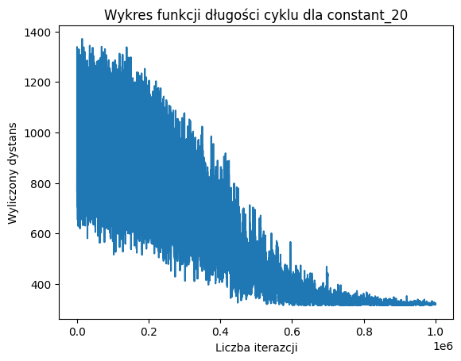

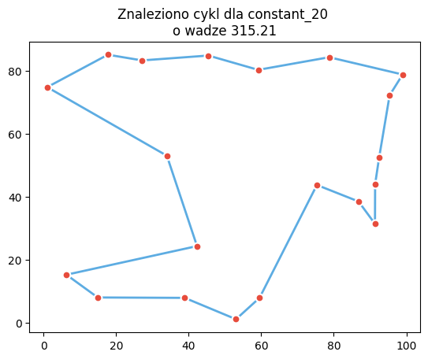

```python
test_tsp(gen_random_points(20,0,100),temp_start=100,loop_limit=1000000, fun_change_par = 0.999996, gif_filename="constant_20" )
```

Jak widzimy, algorytm dobrze poradził sobie z prostym przykładem testowym. Na wykresie spadku funkcji minimalizującej widać duże wachania na początku, ktore stopniowo zanikają. Doskonale tu widać idee algorytmu bazującym na wyżażaniu, czyli dużym wachaniom na początku, po których następują faza wyciszenia, gdzie funkcja jest optymalizowana tylko wzdłuż gradientu

[figure not shown]

Na gifie dobrze widać jak z początkowego haosu i częstych zmian wyłania się poprawne rozwiązanie problemu.

#### Rozkład normalny na rogach kwadratu

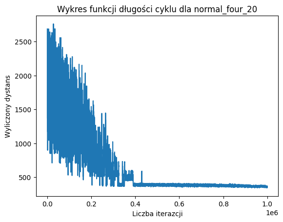

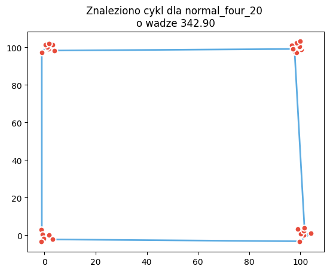

```python
test_tsp(gen_four_spots(30,0,100),temp_start=100,loop_limit=1000000, fun_change_par = 0.999996, gif_filename="normal_four_20" )
```

Algorytm szybko znalazł rozwiązanie, które nie zawierało przekątnych, a następnie przystąpił do dalszej optymalizacji samej trasy w obrębie skupisk punktów, dążąc do poprawy jej efektywności.

[figure not shown]

Animacja GIF doskonale ilustruje, jak algorytm szybko osiągnął rozwiązanie zbliżone do optymalnego. Znaczną część czasu poświęcił natomiast na mikrooptymalizacje w późniejszym etapie, starając się jeszcze bardziej poprawić jakość uzyskanej trasy.

#### Rozkład normalny na dziewięciu skupiskach

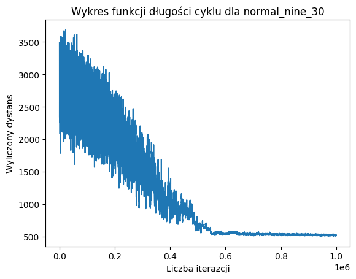

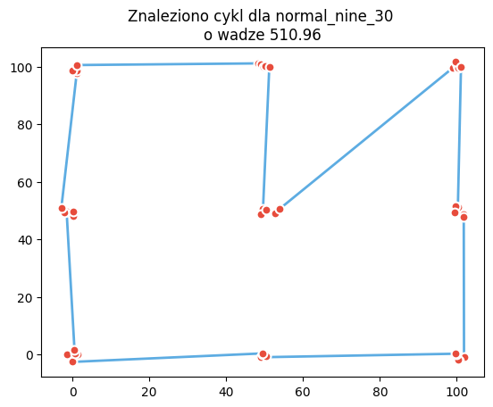

```python
test_tsp(gen_nine_spots(45,0,100),temp_start=100,loop_limit=1000000, fun_change_par = 0.999996, gif_filename="normal_nine_30" )
```

[figure not shown]

### Porównaie metod generowania sąsiedniego stanu

#### Rozkład jednostajny

Dla nepszego zobrazowania różnic między strukturami, oba algorytmy są uruchamine z tymi samymi parametrami i funkcjami wyżażania

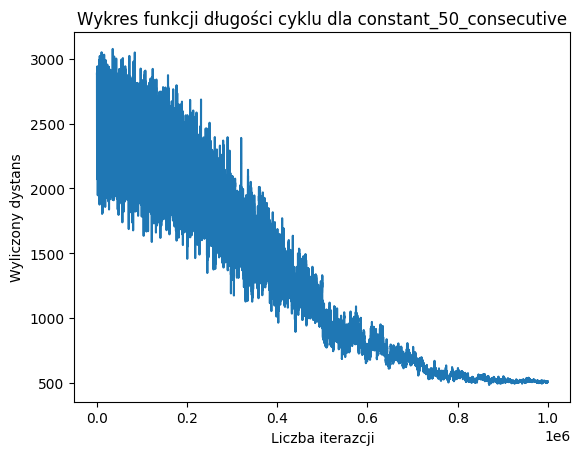

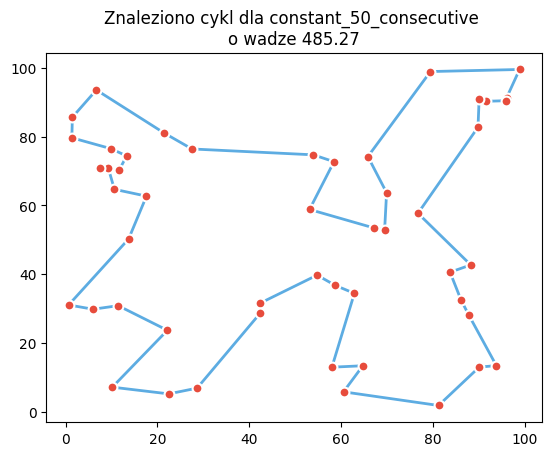

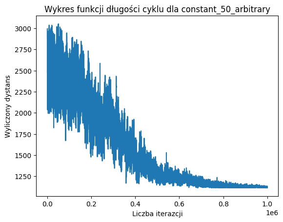

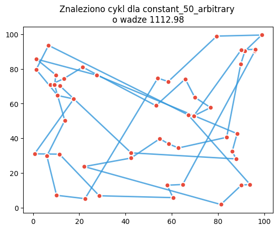

```python
set = gen_random_points(50,0,100)
test_tsp(set,temp_start=100,loop_limit=1000000, fun_change_par = 0.999996, gif_filename="constant_50_consecutive" )
test_tsp(set,temp_start=100,loop_limit=1000000, fun_change_par = 0.999996, gif_filename="constant_50_arbitrary", arbitrary=True )
```

Warto podkreślić, że dla większych wartości n algorytm nie gwarantuje znalezienia optymalnej trasy. Zwracane rozwiązanie stanowi jedynie dobrą aproksymację, która — mimo braku optymalności — może być wystarczająco efektywna w praktyce.

Gify powstawania obu dróg:

[figure not shown]

Na gifach wyraźnie widać mniej dynamiczne zmiany dla `arbitrary swap`

#### Rozkład normalny na 4 skupiskach

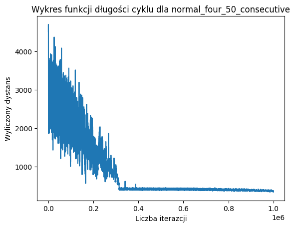

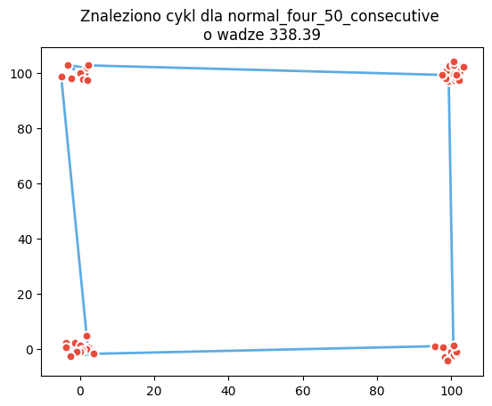

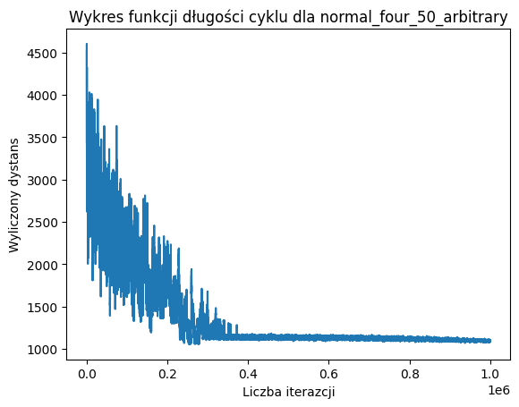

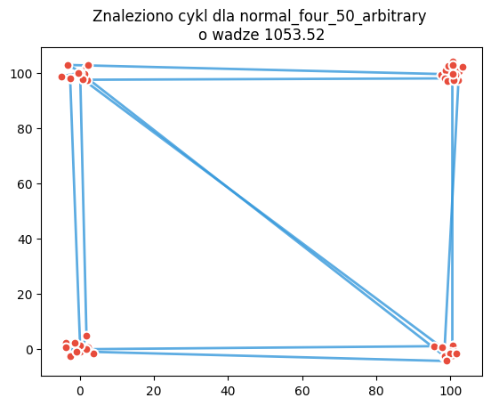

```python
set = gen_four_spots(50,0,100)
test_tsp(set,temp_start=100,loop_limit=1000000, fun_change_par = 0.999996, gif_filename="normal_four_50_consecutive" )
test_tsp(set,temp_start=100,loop_limit=1000000, fun_change_par = 0.999996, gif_filename="normal_four_50_arbitrary", arbitrary=True )
```

#### Rozkład normalny na 9 skupiskach

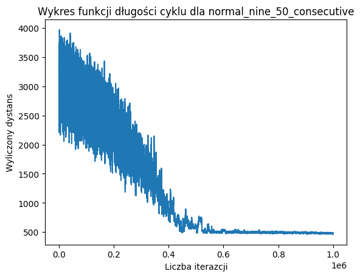

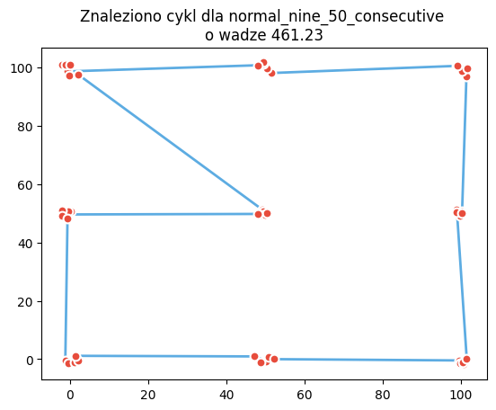

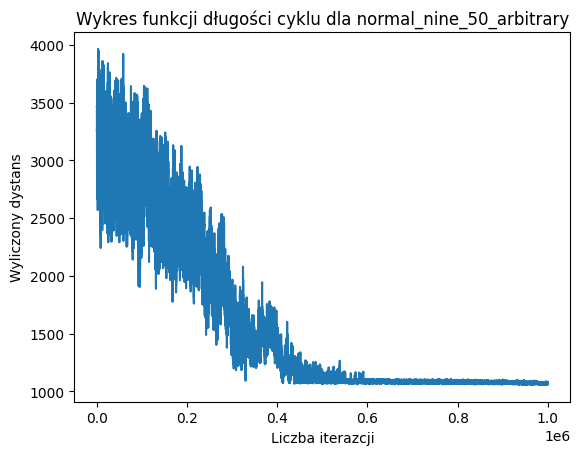

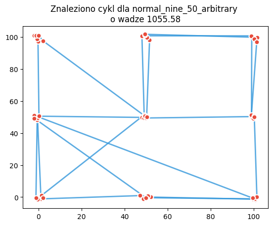

```python
set = gen_nine_spots(50,0,100)
test_tsp(set,temp_start=100,loop_limit=1000000, fun_change_par = 0.999996, gif_filename="normal_nine_50_consecutive" )
test_tsp(set,temp_start=100,loop_limit=1000000, fun_change_par = 0.999996, gif_filename="normal_nine_50_arbitrary", arbitrary=True, min_heat=10**(-2) )
```

Po raz kolejny `consecutivep` wygrywa. W tym przypadku widać duże zagrzebanie się na minimum lokalnym algorytmu zamist skupieniu się na minimum gloablnym

Podsumowanie: Dla problemu komiwojażera przy algorytmie wyżażania lepszą techniką jest `consecutive swap`

### Porównanie różnych funkcji wyżażania

#### Rozkład jednostajny

- Funkcja liniowa: $ T_k = T_0 - a * k $

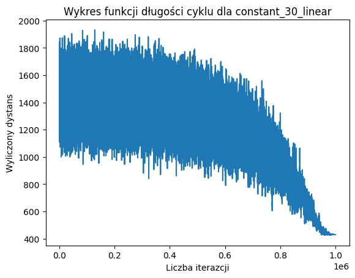

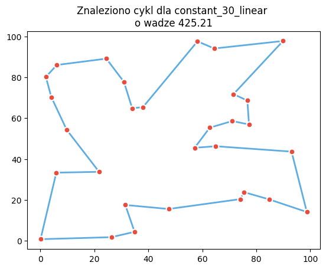

```python
set = gen_random_points(30,0,100)
test_tsp(set,temp_start=100,loop_limit=1000000, fun_change_par = 1/10001,fun_temp_change=update_temp_linear, gif_filename="constant_30_linear" )
```

Jak można zaobserwować, funkcja liniowa znalazła sensowne rozwiązanie problemu. Na szczególną uwagę zasługuje wykres przebiegu funkcji optymalizowanej. Przedstawia on długą i szeroką "harmonijkę", która jest efektem stosunkowo wolnego spadku temperatury podczas całego procesu działania algorytmu. Taki kształt wykresu wskazuje na stopniową, ale konsekwentną optymalizację, z charakterystycznym długotrwałym poszukiwaniem lepszych rozwiązań w początkowej fazie algorytmu.

[figure not shown]

Na animacji GIF wyraźnie widać, jak przez długi czas algorytm eksploruje różne kombinacje, a dopiero pod koniec dochodzi do istotnej optymalizacji długości trasy. Algorytm, będąc już w sensownym minimum, na końcowym etapie intensyfikuje poszukiwania, zstępując w kierunku optymalizacji, przypominającej ruch po gradiencie.

- Funkcja ciągu geometrycznego: $ T_k = T_0 * a^k $

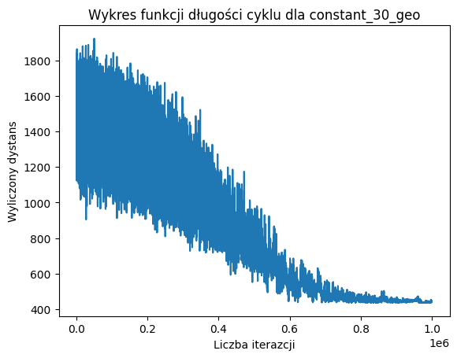

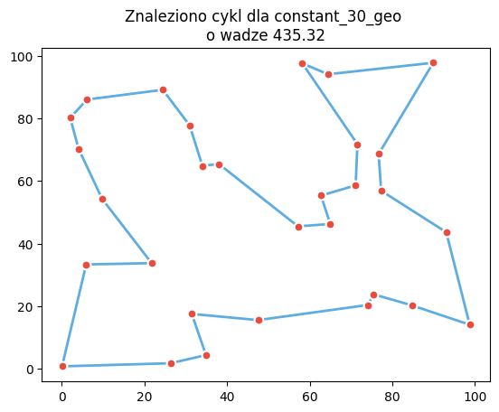

```python
test_tsp(set,temp_start=100,loop_limit=1000000, fun_change_par = 0.999996,fun_temp_change=update_temp_geo, gif_filename="constant_30_geo" )
```

[figure not shown]

Animacja GIF doskonale ilustruje, jak początkowo szybko znajduje się rozwiązanie bazowe, które następnie jest stopniowo udoskonalane w trakcie działania algorytmu.

- Funkcja logarytmiczna: $ T_k = T_0 / {log(1+k)} $

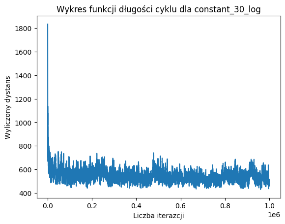

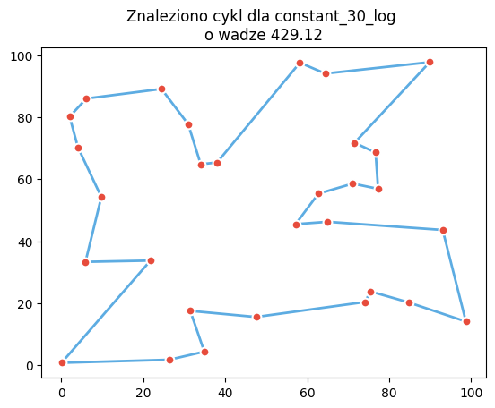

```python
test_tsp(set,temp_start=100,loop_limit=1000000, fun_change_par = None,fun_temp_change=update_temp_log, gif_filename="constant_30_log" )
```

Charakterystyka funkcji logarytmicznej polega na szybkim przejściu po gradiencie w poszukiwaniu jednej cykl, a następnie na stopniowym, lecz różnorodnym udoskonalaniu już znalezionego rozwiązania. Funkcja ta wykazuje silną tendencję do specjalizowania się w jednym minimum, do którego algorytm dociera na początku, a następnie intensywnie poszukuje najlepszej trasy w jego obrębie. Proces ten charakteryzuje się znaczną zmiennością w czasie, co pozwala na efektywniejsze dostosowanie cykl do optymalnych rozwiązań.

[figure not shown]

Warto zwrócić uwagę, że pod koniec procesu algorytm nie ogranicza się do drobnych poprawek w obrębie całej cykl. Zamiast tego, nadal zachodzi intensywna zmiana elementów trasy, mająca na celu znalezienie lepszego minimum, co świadczy o kontynuacji poszukiwań nawet w późniejszej fazie optymalizacji.

#### Rozkład normalny na 4 skupiskach

- Funkcja liniowa: $ T_k = T_0 - a * k $

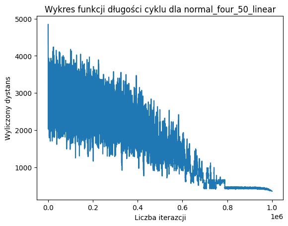

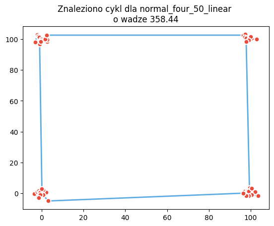

```python
set = gen_four_spots(50,0,100)
test_tsp(set,temp_start=100,loop_limit=1000000, fun_change_par = 1/10001,fun_temp_change=update_temp_linear, gif_filename="normal_four_50_linear" )
```

W tym przypadku również widoczna jest długa harmonijka, która stopniowo opada w kierunku minimum. Szybszy spadek wynika z faktu, że algorytm początkowo znajduje dobre ułożenie w postaci cyklu pozbawionego przekątnych. Po osiągnięciu tego rozwiązania, następuje dalsza optymalizacja, koncentrująca się na doskonaleniu struktury ścieżki w obrębie poszczególnych grup punktów.

[figure not shown]

Ta gifie widać dużą dynamike zmian oraz krótki etap poprawy w obrębie grup

- Funkcja ciągu geometrycznego: $ T_k = T_0 * a^k $

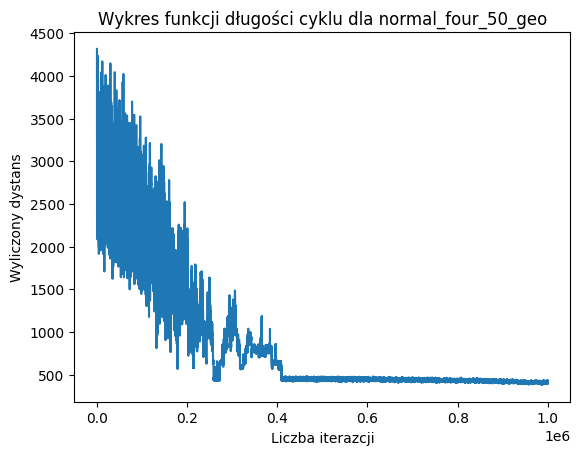

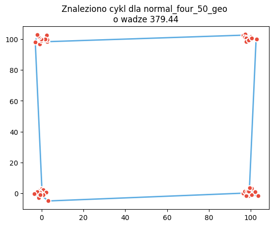

```python
test_tsp(set,temp_start=100,loop_limit=1000000, fun_change_par = 0.999996,fun_temp_change=update_temp_geo, gif_filename="normal_four_50_geo" )
```

Funkcja potęgowa ma dużo krótszą "harmonijke", ale to działa na jej korzyść ze względu na szybkie znalezienie poprawnego rozwiązania (bez przekątnych) i późniejszego jego tylko optymalizowanie. Pomimo lepszych predyspozycji, nie udało się jej pobić wyniku funkcji liniowej

[figure not shown]

Gif ponownie ładnie obrazuje szybkie zejście do poprawnego rozwiązania

- Funkcja logarytmiczna: $ T_k = T_0 / {log(1+k)} $

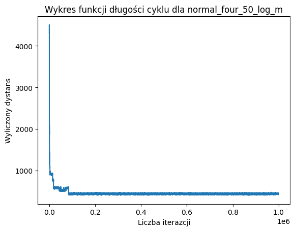

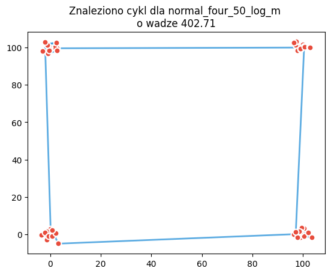

```python
test_tsp(set,temp_start=100,loop_limit=1000000, fun_change_par = None,fun_temp_change=update_temp_log, gif_filename="normal_four_50_log_m" )
```

Obserwujemy szybkie obniżenie wartości funkcji celu do satysfakcjonującego poziomu, po czym następuje stagnacja na osiągniętym wyniku. Przyczyną tego zjawiska może być zbyt niska temperatura, ograniczająca możliwość dalszej eksploracji przestrzeni rozwiązań. W związku z tym warto rozważyć zwiększenie wartości początkowej temperatury.

Po zwiększeniu temperatury początkowej

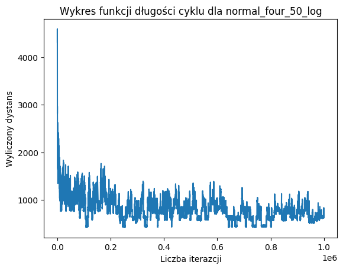

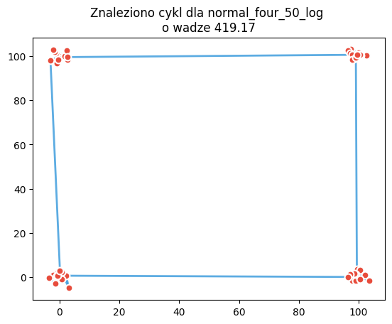

```python
test_tsp(set,temp_start=400,loop_limit=1000000, fun_change_par = None,fun_temp_change=update_temp_log, gif_filename="normal_four_50_log" )
```

Pomimo zwiększenia temperatury uzyskaliśmy wynik gorszy niż poprzednio.

Funkcja logarytmiczna pomimo znalezienia poprawnego rozwiązania, zatrzymuje się w stagnacji

[figure not shown]

#### Rozkład normalny na 9 skupiskach

- Funkcja liniowa: $ T_k = T_0 - a * k $

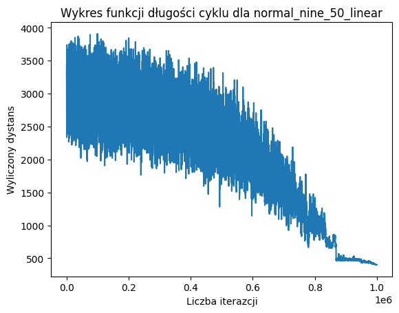

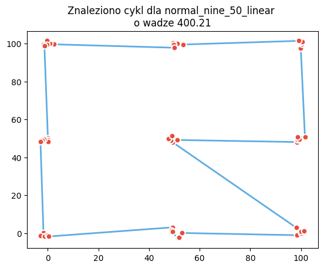

```python
set = gen_nine_spots(50,0,100)
test_tsp(set,temp_start=100,loop_limit=1000000, fun_change_par = 1/10001,fun_temp_change=update_temp_linear, gif_filename="normal_nine_50_linear" )
```

Funkcja liniowa ponownie bardzo dobrze poradziła sobie z problemem. Duża zmienność na początku skutecznie naprowadziła ją na porpawne rozwiązanie

[figure not shown]

Na gifie ponownie widzimy dużą zmienność, która stabilizuje się dopiero na końcu

- Funkcja ciągu geometrycznego: $ T_k = T_0 * a^k $

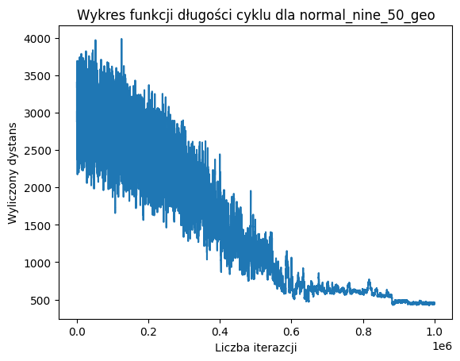

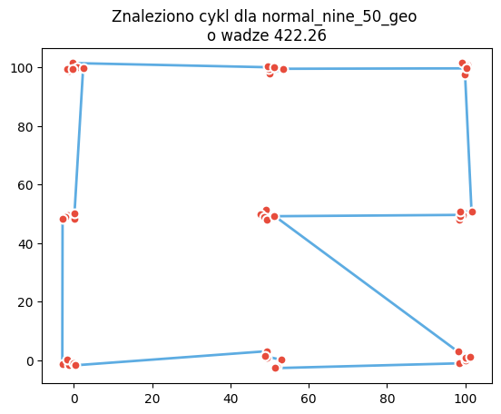

```python
test_tsp(set,temp_start=100,loop_limit=1000000, fun_change_par = 0.999997,fun_temp_change=update_temp_geo, gif_filename="normal_nine_50_geo" )
```

Pomimo znalezienia dobrego rozwiązania ponownie wartość minimalizowanej funkcji jest wyższa niż dla funkcji liniowej

- Funkcja logarytmiczna: $ T_k = T_0 / {log(1+k)} $

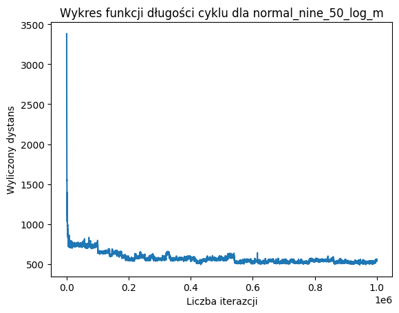

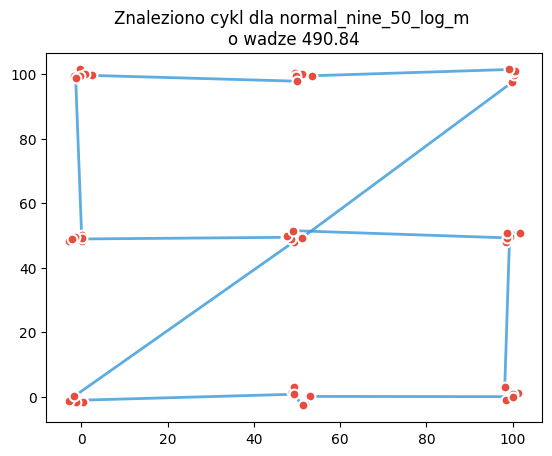

```python
test_tsp(set,temp_start=100,loop_limit=1000000, fun_change_par = None,fun_temp_change=update_temp_log, gif_filename="normal_nine_50_log_m" )
```

Po raz kolejny obserwujemy szybkie obniżenie wartości funkcji celu do satysfakcjonującego poziomu, po czym następuje stagnacja na osiągniętym wyniku. Przyczyną tego zjawiska może być zbyt niska temperatura, ograniczająca możliwość dalszej eksploracji przestrzeni rozwiązań. Zwiększmy wartości początkowej temperatury.

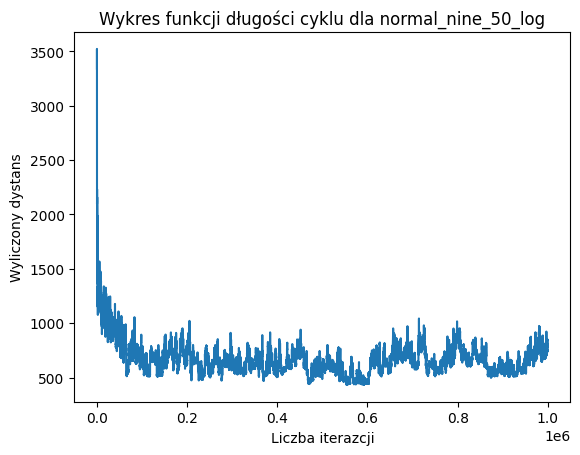

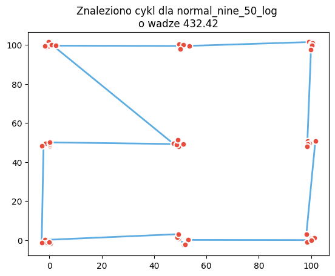

```python
test_tsp(set,temp_start=200,loop_limit=1000000, fun_change_par = None,fun_temp_change=update_temp_log, gif_filename="normal_nine_50_log" )
```

Tym razem po zwiększeniu temperatury jest lepiej

[figure not shown]

Podsumowanie:

- W przypadku problemu komiwojażera, najlepsze rezultaty uzyskano przy zastosowaniu funkcji liniowej do opisu spadku temperatury.
- Funkcja logarytmiczna, mimo swojego potencjału w kontekście różnorodnej eksploracji rozwiązań, wymaga wyższej temperatury początkowej w przypadku punktów skupionych, aby skutecznie znaleźć cykl bliski optymalnemu — choć nie jest to regułą.
- Funkcja oparta na ciągu geometrycznym, pomimo obiecującej charakterystyki szybkiego odnajdywania poprawnego cyklu, nie osiąga jakości rozwiązań porównywalnej z funkcją liniową.

#### Test dla dużej liczby punktów

#### Rozkład ciągły

Przetestujmy teraz działanie algorytmu przy dwóch różnych wartościach temperatury początkowej (100 i 200), zwiększonej liczbie iteracji oraz odpowiednio dostosowanym parametrze wygaszania temperatury.

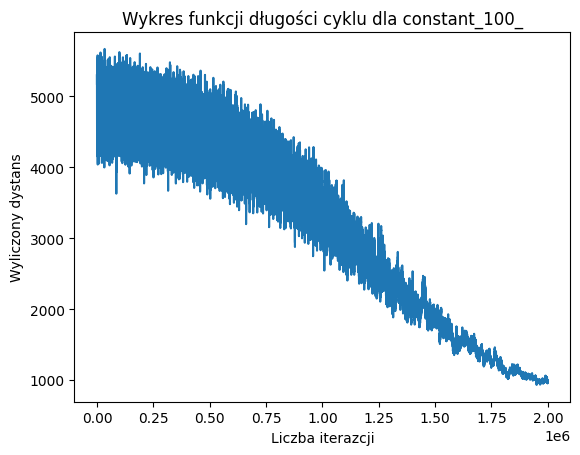

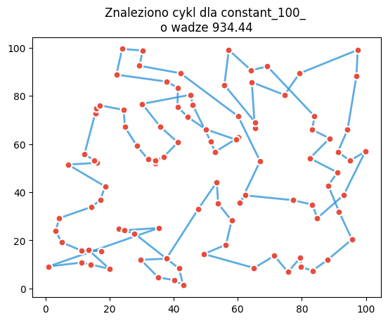

```python
test_tsp(gen_random_points(100,0,100),temp_start=200,loop_limit=2000000, fun_change_par = 0.999998, gif_filename="constant_100_" )
```

[figure not shown]

Algorytm zwrócił ścieżkę, która nie jest rozwiązaniem idealnym — można było osiągnąć lepszy wynik. Przeanalizujmy teraz przypadek z dwukrotnie mniejszą temperaturą początkową.

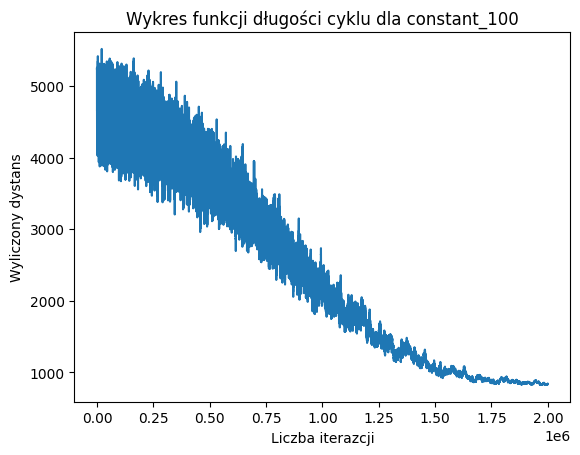

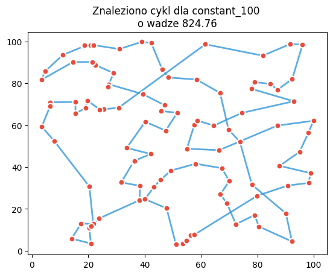

```python
test_tsp(gen_random_points(100,0,100),temp_start=100,loop_limit=2000000, fun_change_par = 0.999998, gif_filename="constant_100" )
```

[figure not shown]

Niestety, dla dużych wartości n algorytm znajduje rozwiązanie o średniej jakości. Dla podwyższeniu temperatury początkowej nie zaobserwowano poprawy

### Rozkład normalny 4 skupiska

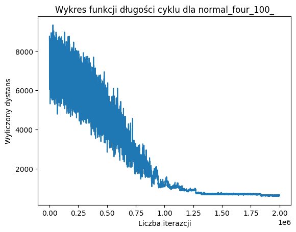

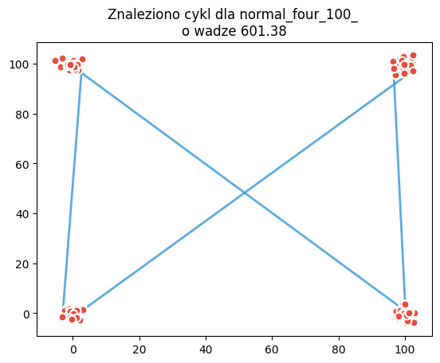

```python
test_tsp(gen_four_spots(100,0,100),temp_start=200,loop_limit=2000000, fun_change_par = 0.9999991, gif_filename="normal_four_100_" )
```

[figure not shown]

Niestety, dla większej liczby punktów zastosowany algorytm nie zdołał odnaleźć odpowiedniego cyklu. Otrzymane rozwiązanie zawiera dwie przekątne, które mogłyby zostać stosunkowo łatwo wyeliminowane w ramach skuteczniejszej optymalizacji.

### Rozkład normalny 9 skupiska

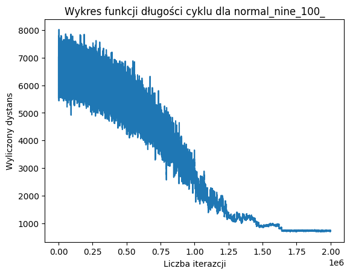

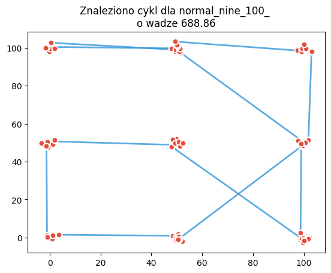

```python
test_tsp(gen_nine_spots(100,0,100),temp_start=200,loop_limit=2000000, fun_change_par = 0.999998, gif_filename="normal_nine_100_" )
```

[figure not shown]

Również tutaj wyłania się problem wpadnięcia w minimum

# Podsumowanie

- Przeprowadzone testy potwierdziły poprawność implementacji algorytmu.
- Najlepsze rezultaty w generowaniu stanów sąsiednich dała technika consecutive swap.
- Spośród przetestowanych funkcji temperatury, najlepszą okazała się funkcja liniowa.
- W przypadku dużej liczby punktów uzyskane rozwiązania mają charakter przybliżony i często odbiegają od optimum.